# Regression applied to diagnosis prediction.

Alexandre Rosa

2023-09-20

## What is the main objective of this code?

This code was built to analyze a database of cancer diagnosis with different classifications and using ETL methods, clean and explore the data. Also, using a *regression model based on different variables to predict the final diagnosis*.

## Database analysis steps:

- Verify and install specific libraries.
- Assign our database to a data frame.
- Explore our data and check inconsistencies as null values.
- Split data into test and training set.
- Create the model based into the training dataset and explore the results.
- Evaluate model based on specific measurement tools.
- Create the model based into the test dataset and explore the results.
- Evaluate model based on specific measurement tools.
- Explore results obtained in data analysis.

## What is the result of this data analysis?

Based on this analysis I was able to understand that we have 3 variables that are able to describe specific diagnosis and forecast more accurately and fast this results.

```r
knitr::opts_chunk$set(echo = TRUE)
```

## CODE

Database: https://archive.ics.uci.edu/dataset/17/breast+cancer+wisconsin+diagnostic

Paper: https://minds.wisconsin.edu/bitstream/handle/1793/59692/TR1131.pdf?sequence=1

```r
# Define the list of packages to load
pacotes <- c("tidyr", "tidyverse", "ggplot2", "readr", "caret", "dplyr", "randomForest", "rpart", "stats","tinytex")

# Install and load missing packages
missing_packages <- pacotes[!pacotes %in% installed.packages()]
if (length(missing_packages) > 0) {
  install.packages(missing_packages, dependencies = TRUE)
}

# Load the required packages and show the result of installation.
sapply(pacotes, require, character = TRUE)
```

```
##        tidyr    tidyverse      ggplot2        readr        caret        dplyr
##         TRUE         TRUE         TRUE         TRUE         TRUE         TRUE
## randomForest        rpart        stats      tinytex
##         TRUE         TRUE         TRUE         TRUE
```

```r
#set working environment if it's not set to the correct..
setwd("C:/Users/user/Documents/R_Programming/Breast_cancer_data_set/")
getwd()
```

```
## [1] "C:/Users/user/Documents/R_Programming/Breast_cancer_data_set"
```

```r
# Get data and explore it

#Read csv file, assign to a variable and view data.
data_h <- read.csv("breast-cancer.csv", sep = ",")

#Explore data analyzing what is inside our database
str(data_h)
```

```
## 'data.frame':    569 obs. of  32 variables:
##  $ id                     : int  842302 842517 84300903 84348301 84358402 843786 844359 84458202 844981 84501001 ...
##  $ diagnosis              : chr  "M" "M" "M" "M" ...
##  $ radius_mean            : num  18 20.6 19.7 11.4 20.3 ...
##  $ texture_mean           : num  10.4 17.8 21.2 20.4 14.3 ...
##  $ perimeter_mean         : num  122.8 132.9 130 77.6 135.1 ...
##  $ area_mean              : num  1001 1326 1203 386 1297 ...
##  $ smoothness_mean        : num  0.1184 0.0847 0.1096 0.1425 0.1003 ...
##  $ compactness_mean       : num  0.2776 0.0786 0.1599 0.2839 0.1328 ...
##  $ concavity_mean         : num  0.3001 0.0869 0.1974 0.2414 0.198 ...
##  $ concave.points_mean    : num  0.1471 0.0702 0.1279 0.1052 0.1043 ...
##  $ symmetry_mean          : num  0.242 0.181 0.207 0.26 0.181 ...
##  $ fractal_dimension_mean : num  0.0787 0.0567 0.06 0.0974 0.0588 ...
##  $ radius_se              : num  1.095 0.543 0.746 0.496 0.757 ...
##  $ texture_se             : num  0.905 0.734 0.787 1.156 0.781 ...
```

[output cut: 18 more lines]

```r
head(data_h,5)
```

```
##         id diagnosis radius_mean texture_mean perimeter_mean area_mean
## 1   842302         M       17.99        10.38         122.80    1001.0
## 2   842517         M       20.57        17.77         132.90    1326.0
## 3 84300903         M       19.69        21.25         130.00    1203.0
## 4 84348301         M       11.42        20.38          77.58     386.1
## 5 84358402         M       20.29        14.34         135.10    1297.0
##   smoothness_mean compactness_mean concavity_mean concave.points_mean
## 1         0.11840          0.27760         0.3001             0.14710
## 2         0.08474          0.07864         0.0869             0.07017
## 3         0.10960          0.15990         0.1974             0.12790
## 4         0.14250          0.28390         0.2414             0.10520
## 5         0.10030          0.13280         0.1980             0.10430
##   symmetry_mean fractal_dimension_mean radius_se texture_se perimeter_se
## 1        0.2419                0.07871    1.0950     0.9053        8.589
## 2        0.1812                0.05667    0.5435     0.7339        3.398
```

[output cut: 27 more lines]

```r
dim(data_h)
```

```
## [1] 569  32
```

```r
summary(data_h)
```

```
##        id             diagnosis          radius_mean      texture_mean
##  Min.   :     8670   Length:569         Min.   : 6.981   Min.   : 9.71
##  1st Qu.:   869218   Class :character   1st Qu.:11.700   1st Qu.:16.17
##  Median :   906024   Mode  :character   Median :13.370   Median :18.84
##  Mean   : 30371831                      Mean   :14.127   Mean   :19.29
##  3rd Qu.:  8813129                      3rd Qu.:15.780   3rd Qu.:21.80
##  Max.   :911320502                      Max.   :28.110   Max.   :39.28
##  perimeter_mean     area_mean      smoothness_mean   compactness_mean
##  Min.   : 43.79   Min.   : 143.5   Min.   :0.05263   Min.   :0.01938
##  1st Qu.: 75.17   1st Qu.: 420.3   1st Qu.:0.08637   1st Qu.:0.06492
##  Median : 86.24   Median : 551.1   Median :0.09587   Median :0.09263
##  Mean   : 91.97   Mean   : 654.9   Mean   :0.09636   Mean   :0.10434
##  3rd Qu.:104.10   3rd Qu.: 782.7   3rd Qu.:0.10530   3rd Qu.:0.13040
##  Max.   :188.50   Max.   :2501.0   Max.   :0.16340   Max.   :0.34540
##  concavity_mean    concave.points_mean symmetry_mean    fractal_dimension_mean
##  Min.   :0.00000   Min.   :0.00000     Min.   :0.1060   Min.   :0.04996
##  1st Qu.:0.02956   1st Qu.:0.02031     1st Qu.:0.1619   1st Qu.:0.05770
##  Median :0.06154   Median :0.03350     Median :0.1792   Median :0.06154
##  Mean   :0.08880   Mean   :0.04892     Mean   :0.1812   Mean   :0.06280
##  3rd Qu.:0.13070   3rd Qu.:0.07400     3rd Qu.:0.1957   3rd Qu.:0.06612
##  Max.   :0.42680   Max.   :0.20120     Max.   :0.3040   Max.   :0.09744
##    radius_se        texture_se      perimeter_se       area_se
##  Min.   :0.1115   Min.   :0.3602   Min.   : 0.757   Min.   :  6.802
##  1st Qu.:0.2324   1st Qu.:0.8339   1st Qu.: 1.606   1st Qu.: 17.850
##  Median :0.3242   Median :1.1080   Median : 2.287   Median : 24.530
##  Mean   :0.4052   Mean   :1.2169   Mean   : 2.866   Mean   : 40.337
##  3rd Qu.:0.4789   3rd Qu.:1.4740   3rd Qu.: 3.357   3rd Qu.: 45.190
##  Max.   :2.8730   Max.   :4.8850   Max.   :21.980   Max.   :542.200
##  smoothness_se      compactness_se      concavity_se     concave.points_se
##  Min.   :0.001713   Min.   :0.002252   Min.   :0.00000   Min.   :0.000000
##  1st Qu.:0.005169   1st Qu.:0.013080   1st Qu.:0.01509   1st Qu.:0.007638
##  Median :0.006380   Median :0.020450   Median :0.02589   Median :0.010930
##  Mean   :0.007041   Mean   :0.025478   Mean   :0.03189   Mean   :0.011796
##  3rd Qu.:0.008146   3rd Qu.:0.032450   3rd Qu.:0.04205   3rd Qu.:0.014710
##  Max.   :0.031130   Max.   :0.135400   Max.   :0.39600   Max.   :0.052790
##   symmetry_se       fractal_dimension_se  radius_worst   texture_worst
##  Min.   :0.007882   Min.   :0.0008948    Min.   : 7.93   Min.   :12.02
##  1st Qu.:0.015160   1st Qu.:0.0022480    1st Qu.:13.01   1st Qu.:21.08
##  Median :0.018730   Median :0.0031870    Median :14.97   Median :25.41
##  Mean   :0.020542   Mean   :0.0037949    Mean   :16.27   Mean   :25.68
##  3rd Qu.:0.023480   3rd Qu.:0.0045580    3rd Qu.:18.79   3rd Qu.:29.72
##  Max.   :0.078950   Max.   :0.0298400    Max.   :36.04   Max.   :49.54
##  perimeter_worst    area_worst     smoothness_worst  compactness_worst
##  Min.   : 50.41   Min.   : 185.2   Min.   :0.07117   Min.   :0.02729
##  1st Qu.: 84.11   1st Qu.: 515.3   1st Qu.:0.11660   1st Qu.:0.14720
##  Median : 97.66   Median : 686.5   Median :0.13130   Median :0.21190
##  Mean   :107.26   Mean   : 880.6   Mean   :0.13237   Mean   :0.25427
##  3rd Qu.:125.40   3rd Qu.:1084.0   3rd Qu.:0.14600   3rd Qu.:0.33910
##  Max.   :251.20   Max.   :4254.0   Max.   :0.22260   Max.   :1.05800
##  concavity_worst  concave.points_worst symmetry_worst   fractal_dimension_worst
##  Min.   :0.0000   Min.   :0.00000      Min.   :0.1565   Min.   :0.05504
##  1st Qu.:0.1145   1st Qu.:0.06493      1st Qu.:0.2504   1st Qu.:0.07146
##  Median :0.2267   Median :0.09993      Median :0.2822   Median :0.08004
##  Mean   :0.2722   Mean   :0.11461      Mean   :0.2901   Mean   :0.08395
##  3rd Qu.:0.3829   3rd Qu.:0.16140      3rd Qu.:0.3179   3rd Qu.:0.09208
##  Max.   :1.2520   Max.   :0.29100      Max.   :0.6638   Max.   :0.20750
```

```r
glimpse(data_h)
```

```
## Rows: 569
## Columns: 32
## $ id                      <int> 842302, 842517, 84300903, 84348301, 84358402, …
## $ diagnosis               <chr> "M", "M", "M", "M", "M", "M", "M", "M", "M", "…
## $ radius_mean             <dbl> 17.990, 20.570, 19.690, 11.420, 20.290, 12.450…
## $ texture_mean            <dbl> 10.38, 17.77, 21.25, 20.38, 14.34, 15.70, 19.9…
## $ perimeter_mean          <dbl> 122.80, 132.90, 130.00, 77.58, 135.10, 82.57, …
## $ area_mean               <dbl> 1001.0, 1326.0, 1203.0, 386.1, 1297.0, 477.1, …
## $ smoothness_mean         <dbl> 0.11840, 0.08474, 0.10960, 0.14250, 0.10030, 0…
## $ compactness_mean        <dbl> 0.27760, 0.07864, 0.15990, 0.28390, 0.13280, 0…
## $ concavity_mean          <dbl> 0.30010, 0.08690, 0.19740, 0.24140, 0.19800, 0…
## $ concave.points_mean     <dbl> 0.14710, 0.07017, 0.12790, 0.10520, 0.10430, 0…
## $ symmetry_mean           <dbl> 0.2419, 0.1812, 0.2069, 0.2597, 0.1809, 0.2087…
## $ fractal_dimension_mean  <dbl> 0.07871, 0.05667, 0.05999, 0.09744, 0.05883, 0…
## $ radius_se               <dbl> 1.0950, 0.5435, 0.7456, 0.4956, 0.7572, 0.3345…
```

[output cut: 19 more lines]

```r
#Check if we have any null values in the data frame.
data_h[is.na(data_h) == TRUE]
```

```
## character(0)
```

```r
#Calculate the number of missing values in each column, in case we have
colSums(is.na(data_h))
```

```
##                      id               diagnosis             radius_mean
##                       0                       0                       0
##            texture_mean          perimeter_mean               area_mean
##                       0                       0                       0
##         smoothness_mean        compactness_mean          concavity_mean
##                       0                       0                       0
##     concave.points_mean           symmetry_mean  fractal_dimension_mean
##                       0                       0                       0
##               radius_se              texture_se            perimeter_se
##                       0                       0                       0
##                 area_se           smoothness_se          compactness_se
##                       0                       0                       0
##            concavity_se       concave.points_se             symmetry_se
##                       0                       0                       0
##    fractal_dimension_se            radius_worst           texture_worst
##                       0                       0                       0
##         perimeter_worst              area_worst        smoothness_worst
##                       0                       0                       0
##       compactness_worst         concavity_worst    concave.points_worst
##                       0                       0                       0
##          symmetry_worst fractal_dimension_worst
##                       0                       0
```

```r
#At this time we need to check if both classification categories have a significant representation in our dataset.
# Count the frequency of each class in the 'Category' column
class_counts <- table(data_h$diagnosis)
# Calculate the percentage of each class
class_percentages <- prop.table(class_counts) * 100
# Create a data frame with counts and percentages
class_summary <- data.frame(Class = names(class_counts), Count = as.numeric(class_counts), Percentage = class_percentages)
# Print the summary table
print(class_summary)
```

```
##   Class Count Percentage.Var1 Percentage.Freq
## 1     B   357               B        62.74165
## 2     M   212               M        37.25835
```

```r
# Prepare data to use and split into test and train data frame.
#Replace data from categorical value to numerical and change the format.
data_h2 <- data_h
data_h2$diagnosis <- ifelse(data_h2$diagnosis == "M",1,
                            ifelse(data_h2$diagnosis == "B",2,
                            data_h2$diagnosis))
data_h2$diagnosis <- as.numeric(data_h2$diagnosis)

# Split Data into Training and Testing in R based on 70% training and 30% for test.
sample_size = floor(0.7*nrow(data_h2))

# Set a random dataset.
set.seed(777)

# randomly split data in test and train using random split created in the last step.
train = sample(seq_len(nrow(data_h2)),size = sample_size)
#split data into train dataset
data_h_train  = data_h2[train ,]
dim(data_h_train)
```

```
## [1] 398  32
```

```r
#split data into testdataset
data_h_test = data_h2[-train,]
dim(data_h_test)
```

```
## [1] 171  32
```

```r
#Create variables to prepare, apply linear regression model and assign it to a variable.
#Create Y variable
nomes <- "diagnosis"
y_variable <- nomes

#Create X variable extracting column names from dataset using a variable.
nomes <- data_h[,3:32]
x_variable <- names(nomes)

#Create complete formula with all column names.
formula_str <- paste(y_variable,"~",paste(x_variable, collapse = " + "))

# Print the formula
cat("Regression Formula:", formula_str, "\n")
```

```
## Regression Formula: diagnosis ~ radius_mean + texture_mean + perimeter_mean + area_mean + smoothness_mean + compactness_mean + concavity_mean + concave.points_mean + symmetry_mean + fractal_dimension_mean + radius_se + texture_se + perimeter_se + area_se + smoothness_se + compactness_se + concavi…
```

```r
#Create a prediction model using variable created to assign column names and show a summary.
model <- lm(formula_str,data= data_h_train)
model %>% summary()
```

```
##
## Call:
## lm(formula = formula_str, data = data_h_train)
##
## Residuals:
##      Min       1Q   Median       3Q      Max
## -0.79611 -0.12315  0.02975  0.16023  0.66050
##
## Coefficients:
##                           Estimate Std. Error t value Pr(>|t|)
## (Intercept)              4.487e+00  5.449e-01   8.235 3.18e-15 ***
## radius_mean              2.907e-02  2.185e-01   0.133   0.8942
## texture_mean            -8.854e-03  1.028e-02  -0.861   0.3897
## perimeter_mean          -5.827e-03  3.229e-02  -0.180   0.8569
## area_mean                1.966e-04  6.460e-04   0.304   0.7611
## smoothness_mean         -1.234e+00  2.449e+00  -0.504   0.6146
## compactness_mean         5.376e+00  1.727e+00   3.113   0.0020 **
## concavity_mean          -1.604e+00  1.323e+00  -1.212   0.2261
## concave.points_mean     -3.529e+00  2.495e+00  -1.414   0.1581
## symmetry_mean           -1.023e-01  9.441e-01  -0.108   0.9137
## fractal_dimension_mean   3.940e-01  7.312e+00   0.054   0.9571
## radius_se               -4.579e-01  4.003e-01  -1.144   0.2533
## texture_se               1.808e-02  4.530e-02   0.399   0.6901
## perimeter_se             1.074e-02  5.322e-02   0.202   0.8402
## area_se                  7.931e-04  1.710e-03   0.464   0.6431
## smoothness_se           -1.238e+01  8.140e+00  -1.520   0.1293
## compactness_se           2.231e+00  3.376e+00   0.661   0.5091
## concavity_se             2.474e+00  2.467e+00   1.003   0.3166
## concave.points_se       -1.209e+01  7.188e+00  -1.682   0.0934 .
## symmetry_se             -1.761e+00  3.216e+00  -0.547   0.5844
## fractal_dimension_se    -1.172e+01  1.711e+01  -0.685   0.4935
## radius_worst            -1.706e-01  7.474e-02  -2.282   0.0231 *
## texture_worst           -6.200e-03  8.756e-03  -0.708   0.4794
## perimeter_worst          3.900e-03  8.288e-03   0.470   0.6383
## area_worst               8.862e-04  4.012e-04   2.209   0.0278 *
## smoothness_worst        -9.053e-01  1.708e+00  -0.530   0.5965
## compactness_worst       -8.258e-01  5.533e-01  -1.492   0.1365
## concavity_worst         -3.420e-02  3.798e-01  -0.090   0.9283
## concave.points_worst    -1.306e-01  1.163e+00  -0.112   0.9107
## symmetry_worst          -7.517e-01  6.221e-01  -1.208   0.2277
## fractal_dimension_worst -2.941e+00  3.407e+00  -0.863   0.3886
## ---
## Signif. codes:  0 '***' 0.001 '**' 0.01 '*' 0.05 '.' 0.1 ' ' 1
##
## Residual standard error: 0.2405 on 367 degrees of freedom
## Multiple R-squared:  0.7741, Adjusted R-squared:  0.7556
## F-statistic: 41.92 on 30 and 367 DF,  p-value: < 2.2e-16
```

```r
#create a summary variable to create a descending order in next charpter.
model_summary <- summary(model)
# Sort the summary by the "Pr(>|t|)" column in ascending order
sorted_summary <- model_summary$coefficients[order(model_summary$coefficients[, "Pr(>|t|)"]), ]

#print summary with ascending order
print(sorted_summary)
```

```
##                              Estimate   Std. Error     t value     Pr(>|t|)
## (Intercept)              4.487144e+00 5.448548e-01  8.23548580 3.180260e-15
## compactness_mean         5.376430e+00 1.727171e+00  3.11285356 1.998239e-03
## radius_worst            -1.705603e-01 7.474406e-02 -2.28192372 2.306571e-02
## area_worst               8.861691e-04 4.012065e-04  2.20876047 2.780867e-02
## concave.points_se       -1.208976e+01 7.187790e+00 -1.68198550 9.342227e-02
## smoothness_se           -1.237728e+01 8.140480e+00 -1.52046121 1.292562e-01
## compactness_worst       -8.257530e-01 5.533477e-01 -1.49228591 1.364833e-01
## concave.points_mean     -3.529248e+00 2.495169e+00 -1.41443236 1.580828e-01
## concavity_mean          -1.604164e+00 1.323138e+00 -1.21239365 2.261416e-01
## symmetry_worst          -7.517420e-01 6.220686e-01 -1.20845522 2.276503e-01
## radius_se               -4.579219e-01 4.002577e-01 -1.14406761 2.533412e-01
## concavity_se             2.473911e+00 2.466671e+00  1.00293505 3.165530e-01
## fractal_dimension_worst -2.940685e+00 3.406932e+00 -0.86314739 3.886201e-01
## texture_mean            -8.854253e-03 1.028214e-02 -0.86112975 3.897288e-01
## texture_worst           -6.199702e-03 8.756449e-03 -0.70801551 4.793850e-01
## fractal_dimension_se    -1.172355e+01 1.710518e+01 -0.68538039 4.935366e-01
## compactness_se           2.231074e+00 3.376122e+00  0.66083928 5.091300e-01
## symmetry_se             -1.760612e+00 3.216317e+00 -0.54740007 5.844366e-01
## smoothness_worst        -9.052717e-01 1.708221e+00 -0.52995009 5.964670e-01
## smoothness_mean         -1.234362e+00 2.449297e+00 -0.50396574 6.145878e-01
## perimeter_worst          3.899458e-03 8.287981e-03  0.47049546 6.382806e-01
## area_se                  7.930998e-04 1.710219e-03  0.46374156 6.431078e-01
## texture_se               1.807930e-02 4.530108e-02  0.39909204 6.900575e-01
## area_mean                1.965733e-04 6.459928e-04  0.30429647 7.610745e-01
## perimeter_se             1.073742e-02 5.321590e-02  0.20177085 8.402077e-01
## perimeter_mean          -5.826833e-03 3.229432e-02 -0.18042902 8.569154e-01
## radius_mean              2.907039e-02 2.185154e-01  0.13303589 8.942379e-01
## concave.points_worst    -1.306217e-01 1.163407e+00 -0.11227509 9.106667e-01
## symmetry_mean           -1.023261e-01 9.440888e-01 -0.10838610 9.137487e-01
## concavity_worst         -3.420335e-02 3.797860e-01 -0.09005953 9.282890e-01
## fractal_dimension_mean   3.939741e-01 7.311516e+00  0.05388405 9.570569e-01
```

```r
# Create a prediction using training data and evaluate the model created based on training dataset.

#add our prediction to a data frame.
data_h_train$train_predicted_value <- stats::predict(model,data_h_train)
```

```r
# Evaluate our predicted model based on different metrics as MAE, MSE and RMSE.

# Calculate the Mean Absolute Error (MAE)
mae <- mean(abs(data_h_train$train_predicted_value - data_h_train$diagnosis))

# Calculate the Mean Squared Error (MSE)
mse <- mean((data_h_train$train_predicted_value - data_h_train$diagnosis)^2)

# Calculate the Root Mean Squared Error (RMSE)
rmse <- sqrt(mse)

# MSE is calculated by taking the average of the squared differences between the predicted values and the actual value
#A lower MSE indicates a better fit of the model to the data.
cat("Mean Squared Error (MSE):", mse, "\n")
```

```
## Mean Squared Error (MSE): 0.05332976
```

```r
#MAE is calculated by taking the average of the absolute differences between the predicted values and the actual values.
#A lower MAE indicates a better fit of the model to the data.
cat("Mean Absolute Error (MAE):", mae, "\n")
```

```
## Mean Absolute Error (MAE): 0.1782873
```

```r
# RMSE is calculated by taking the square root of the MSE.
cat("Root Mean Squared Error (RMSE):", rmse, "\n")
```

```
## Root Mean Squared Error (RMSE): 0.2309324
```

```r
#Create an evaluation based on confusion matrix, sensitivity and specificity.
#Convert data to numeric, than we can use it.
data_h_train$train_predicted_value <- ifelse(data_h_train$train_predicted_value>1.4, 2, 1)

#Create a confusion matrix
confusion_matrix_train <- caret::confusionMatrix(factor(data_h_train$train_predicted_value), factor(data_h_train$diagnosis))
print(confusion_matrix_train)
```

```
## Confusion Matrix and Statistics
##
##           Reference
## Prediction   1   2
##          1 128   1
##          2  24 245
##
##                Accuracy : 0.9372
##                  95% CI : (0.9087, 0.9589)
##     No Information Rate : 0.6181
##     P-Value [Acc > NIR] : < 2.2e-16
##
##                   Kappa : 0.863
##
##  Mcnemar's Test P-Value : 1.083e-05
##
##             Sensitivity : 0.8421
##             Specificity : 0.9959
##          Pos Pred Value : 0.9922
##          Neg Pred Value : 0.9108
##              Prevalence : 0.3819
##          Detection Rate : 0.3216
##    Detection Prevalence : 0.3241
##       Balanced Accuracy : 0.9190
##
##        'Positive' Class : 1
##
```

```r
# Retrieve sensitivity and specificity from the confusion matrix object
sensitivity <- confusion_matrix_train$byClass["Sensitivity"]
specificity <- confusion_matrix_train$byClass["Specificity"]

# Print sensitivity and specificity
#Sensitivity: is also called the true positive rate and is exactly equal to recall.
cat("Sensitivity:", sensitivity, "\n")
```

```
## Sensitivity: 0.8421053
```

```r
#Specificity: is also called the true negative rate and is equal to TN/(TN+FP)
cat("Specificity:", specificity, "\n")
```

```
## Specificity: 0.995935
```

```r
# Now we need to calculate prediction based on test data and evaluate it.

#create a prediction using test set, based in model that was based on training model
data_h_test$test_predicted_value <- stats::predict(model,data_h_test)
```

```r
# Calculate the Mean Absolute Error (MAE)
mae <- mean(abs(data_h_test$test_predicted_value - data_h_test$diagnosis))

# Calculate the Mean Squared Error (MSE)
mse <- mean((data_h_test$test_predicted_value - data_h_test$diagnosis)^2)

# Calculate the Root Mean Squared Error (RMSE)
rmse <- sqrt(mse)

cat("Mean Squared Error (MSE):", mse, "\n")
```

```
## Mean Squared Error (MSE): 0.05978929
```

```r
cat("Mean Absolute Error (MAE):", mae, "\n")
```

```
## Mean Absolute Error (MAE): 0.2030555
```

```r
cat("Root Mean Squared Error (RMSE):", rmse, "\n")
```

```
## Root Mean Squared Error (RMSE): 0.2445185
```

```r
#Convert data to numeric, than we can use it.
data_h_test$test_predicted_value <- ifelse(data_h_test$test_predicted_value>1.4, 2, 1)

#Create a confusion matrix
confusion_matrix_test <- caret::confusionMatrix(factor(data_h_test$test_predicted_value), factor(data_h_test$diagnosis))
print(confusion_matrix_test)
```

```
## Confusion Matrix and Statistics
##
##           Reference
## Prediction   1   2
##          1  52   0
##          2   8 111
##
##                Accuracy : 0.9532
##                  95% CI : (0.9099, 0.9796)
##     No Information Rate : 0.6491
##     P-Value [Acc > NIR] : < 2e-16
##
##                   Kappa : 0.8941
##
##  Mcnemar's Test P-Value : 0.01333
##
##             Sensitivity : 0.8667
##             Specificity : 1.0000
##          Pos Pred Value : 1.0000
##          Neg Pred Value : 0.9328
##              Prevalence : 0.3509
##          Detection Rate : 0.3041
##    Detection Prevalence : 0.3041
##       Balanced Accuracy : 0.9333
##
##        'Positive' Class : 1
##
```

```r
# Retrieve sensitivity and specificity from the confusion matrix object
sensitivity <- confusion_matrix_test$byClass["Sensitivity"]
specificity <- confusion_matrix_test$byClass["Specificity"]

# Print sensitivity and specificity
#Sensitivity: is also called the true positive rate and is exactly equal to recall.
cat("Sensitivity:", sensitivity, "\n")
```

```
## Sensitivity: 0.8666667
```

```r
#Specificity: is also called the true negative rate and is equal to TN/(TN+FP)
cat("Specificity:", specificity, "\n")
```

```
## Specificity: 1
```

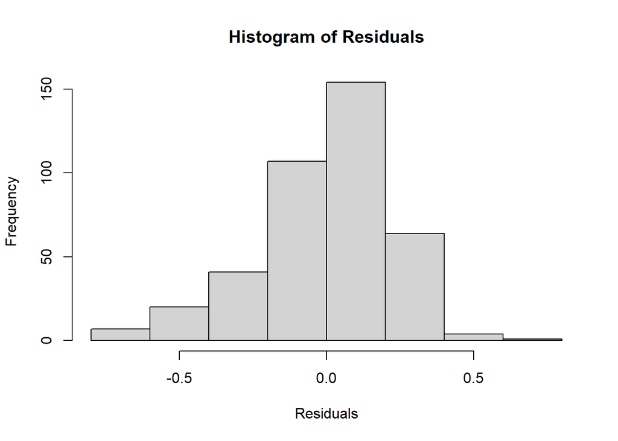

```r
# Calculate the residuals
residuals <- residuals(model)
# Create a histogram of residuals
hist(residuals, main = "Histogram of Residuals", xlab = "Residuals")
```

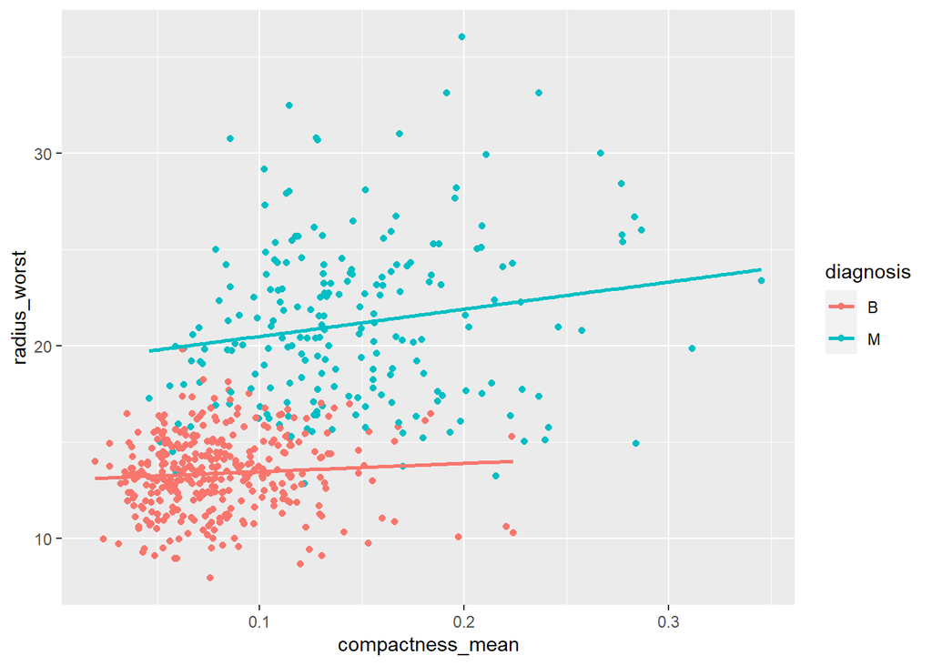

```r
# Graph analysis to show two main variables that split result of regression analysis.
#Compactness mean and radius worst
ggplot(data_h, aes(x=compactness_mean,
                   y=radius_worst,
                   col=diagnosis))+
         geom_point()+
         geom_smooth(method='lm', se = FALSE)
```

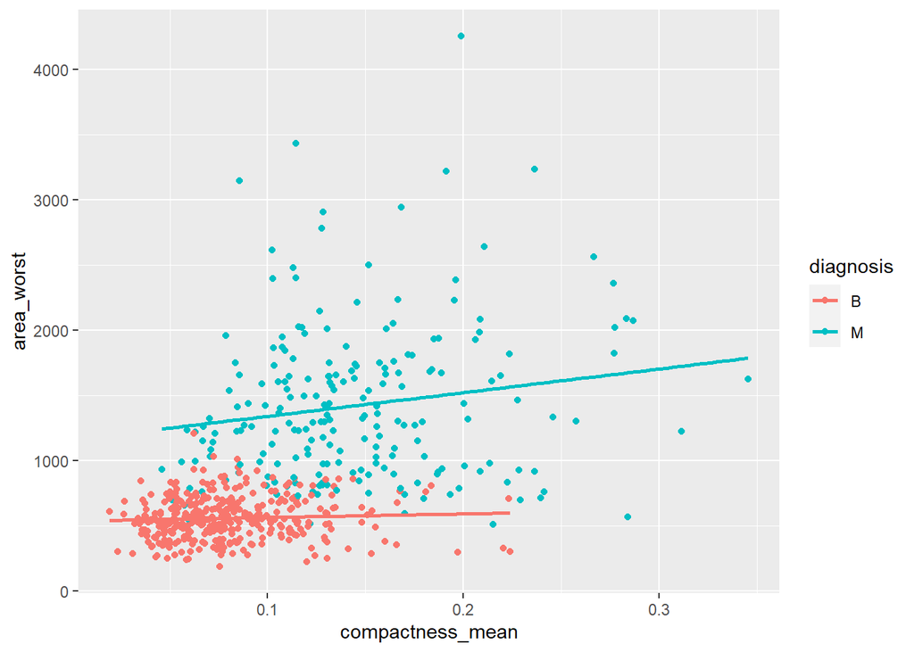

```r
# Graph analysis to show two main variables that split result of regression analysis.
#Compactness mean and area worst
ggplot(data_h, aes(x=compactness_mean,
                   y=area_worst,
                   col=diagnosis))+
         geom_point()+
         geom_smooth(method='lm', se = FALSE)
```

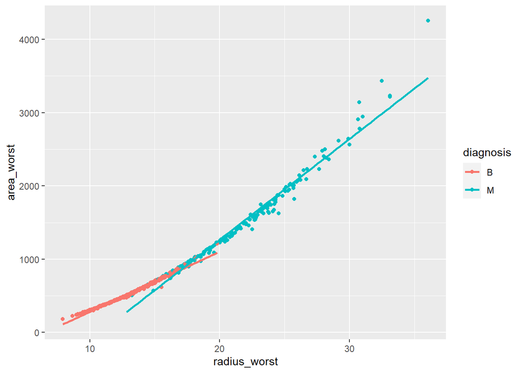

```r
# Graph analysis to show two main variables that split result of regression analysis.
#Compactness mean and area worst
ggplot(data_h, aes(x=radius_worst,
                   y=area_worst,
                   col=diagnosis))+
         geom_point()+
         geom_smooth(method='lm', se = FALSE)
```

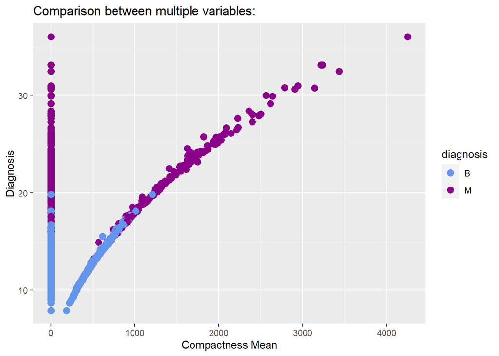

```r
#This final graph shows the relationship between three variables compactness_mean, radius_worst and area_worst.

#First I added a scatterplot comparing compactness_mean and radius_worst based in diagnosis result(left analysis in graph)

multiple_graph_regression <- ggplot(data_h, aes(x = compactness_mean, y = radius_worst, color = diagnosis)) +
  geom_point(size = 3) +

#Then I added a comparison between compactness_mean and area_worst based in diagnosis result in the same graph(right analysis in graph).

  geom_point(aes(x = area_worst), size = 3) +
  labs(title = "Comparison between multiple variables:",
       x = "Compactness Mean",
       y = "Diagnosis") +
  scale_color_manual(values = c("M" = "darkmagenta", "B" = "cornflowerblue"))

# Show the combined plot
print(multiple_graph_regression)
```